# Tweet Sentiment Extraction

Anthony Pan

2020-07-01

## Introduction

The goal of this project is to predict the word or phrase from a tweet that captures its provided sentiment. We are given a training dataset with an original tweet, its sentiment, and the selected text that captures its sentiment.

The metric in this competition is the [word-level Jaccard score](https://en.wikipedia.org/wiki/Jaccard_index). A description of Jaccard similarity for strings can be found [here](https://towardsdatascience.com/overview-of-text-similarity-metrics-3397c4601f50).

This script takes ~1 minute to compile with the help of an RData file where a lot of computationally heavy lifting has already been done.

```r
train <- read.csv("train.csv")
test <- read.csv("test.csv")
sample_submission <- read.csv("sample_submission.csv")
```

The training data has 27,481 tweets, and the test data has 3,534 tweets. Let’s implement the evaluation method first.

```r
# modified jaccard score to take into account repeated words
jaccard <- function (str1, str2) {
  a = str_split(str_to_lower(str1), " ", simplify = TRUE) # lowercase, split
  b = str_split(str_to_lower(as.character(str2)), " ", simplify = TRUE)  # lowercase, split
  c = b[b %in% intersect(a, b)]
  return(length(c) / (length(a) + length(b) - length(c)))
}
```

## Basic Cleaning

1. Remove one tweet that is blank.
2. Remove leading and trailing spaces.
3. Change the data type of text to “character” for easy manipulation.
4. Remove any weird rows where *none* of the selected text contains words from the original text split from spaces. Note that these likely are human annotation errors and also exist in the test data set.

```r
## remove one row in train with blank tweet
train <- train[!(train$text == ""), ]

## change to character
train$text <- as.character(train$text)
train$selected_text <- as.character(train$selected_text)
test$text <- as.character(test$text)

## remove leading and trailing spaces, then add one leading space
# create function
rm_spaces <- function (x) {
  x <- x %>%
    str_remove("^ +") %>%
    str_remove(" +$")
  # paste0(" ", x, " ")
}

# apply function
train <- train %>%
  mutate(text_clean = rm_spaces(text))
test <- test %>%
  mutate(text_clean = rm_spaces(text))

## columns for text similarity with selected text
train$jaccard <- 0
for (i in 1:nrow(train)) {
  train$jaccard[i] <-  jaccard(train$text_clean[i], train$selected_text[i])
}
rm(i)

## note there are rows with weird selected text (words not created by spaces, extra chars) ...i'll remove for now
# train %>%
#   filter(jaccard == 0) %>%
#   select("text", "selected_text")
#
weird_train <- train[(train$jaccard == 0), ]
train <- train[!(train$jaccard == 0), ]

# remove some weird characters
train$text_clean <- str_replace_all(train$text_clean, "ï|¿|½", "")
test$text_clean <- str_replace_all(test$text_clean, "ï|¿|½", "")
```

## Data Exploration

### Sentiment Distribution

The most common sentiment is neutral (~41%), followed by positive (~31%) and negative (~28%) in both training and test datasets.

```r
rbind(train = summary(train$sentiment) / length(train$sentiment),
      test = summary(test$sentiment) / length(test$sentiment)) %>%
  kable() %>%
  kable_styling(bootstrap_options = c("condensed", "responsive", "hover"), full_width = F)
```

|  | negative | neutral | positive |
| --- | --- | --- | --- |
| train | 0.2790136 | 0.4125970 | 0.3083893 |
| test | 0.2832484 | 0.4046406 | 0.3121109 |

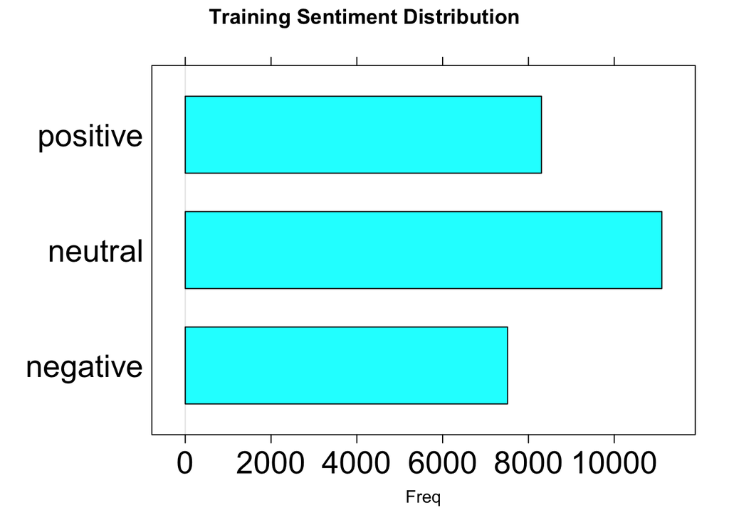

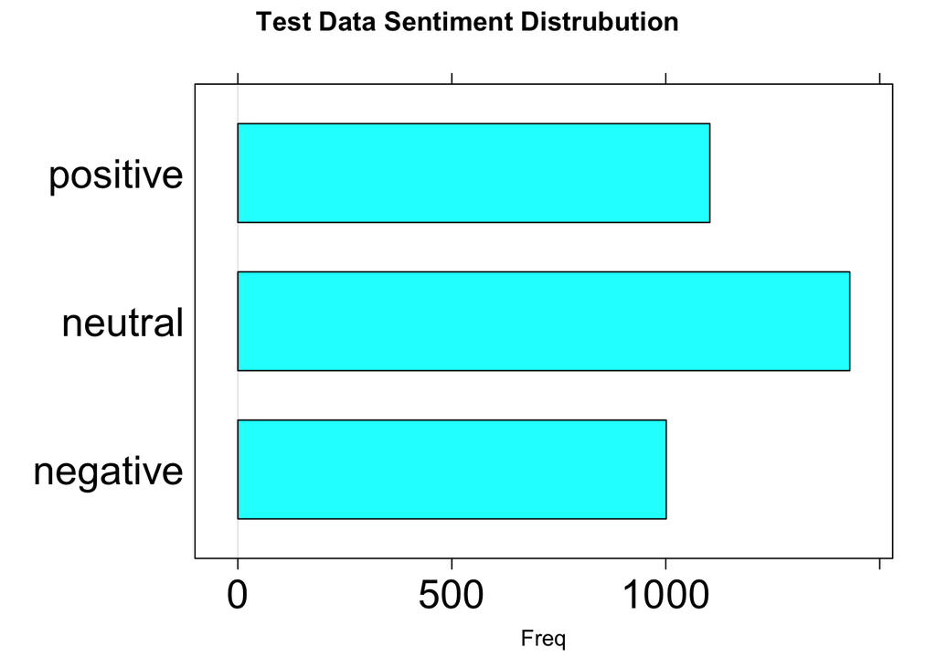

```r
barchart(train$sentiment, main = "Training Sentiment Distribution",
         scales = list(cex = c(1.8, 1)))
barchart(test$sentiment, main = "Test Data Sentiment Distrubution",
         scales = list(cex = c(1.8, 1)))
```

### Comparing Selected and Original

Neutral sentiments are very often captured best by the entire tweet, while positive and negative sentiments are most commonly captured by a couple of key words.

```r
# proportion of selected text that is exactly the same
train$exact_same <- as.character(train$text_clean) == as.character(train$selected_text)
train %>%
  group_by(sentiment) %>%
  summarize(exact_same = sum(exact_same),
            total_tweets = n(),
            proportion_same = exact_same/total_tweets) %>%
  kable() %>%
  kable_styling(bootstrap_options = c("striped", "condensed", "hover"), full_width = F)
```

| sentiment | exact_same | total_tweets | proportion_same |
| --- | --- | --- | --- |
| negative | 1139 | 7513 | 0.1516039 |
| neutral | 9947 | 11110 | 0.8953195 |
| positive | 1115 | 8304 | 0.1342726 |

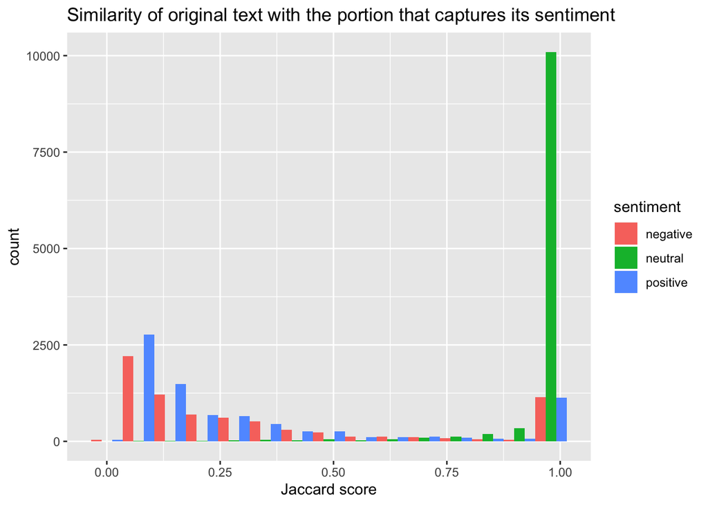

```r
train %>%
  ggplot() +
  geom_histogram(mapping = aes(x = jaccard, fill = sentiment),
                 position = 'dodge',
                 bins = 15) +
  labs(title = "Similarity of original text with the portion that captures its sentiment",
       x = "Jaccard score")
```

### Word Clouds

Just for fun, here are wordclouds of the selected text for positive, neutral, and negative tweets.

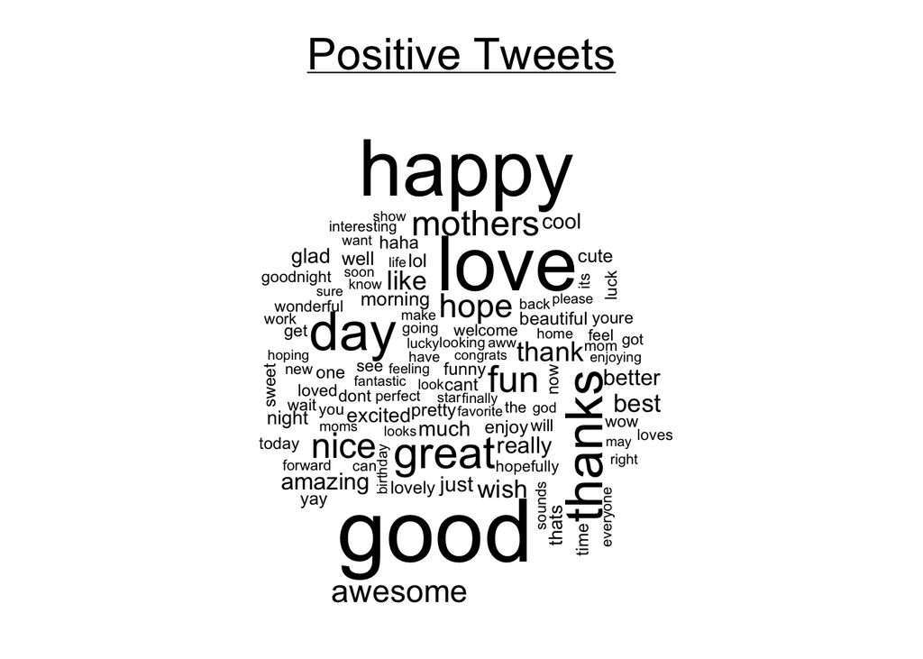

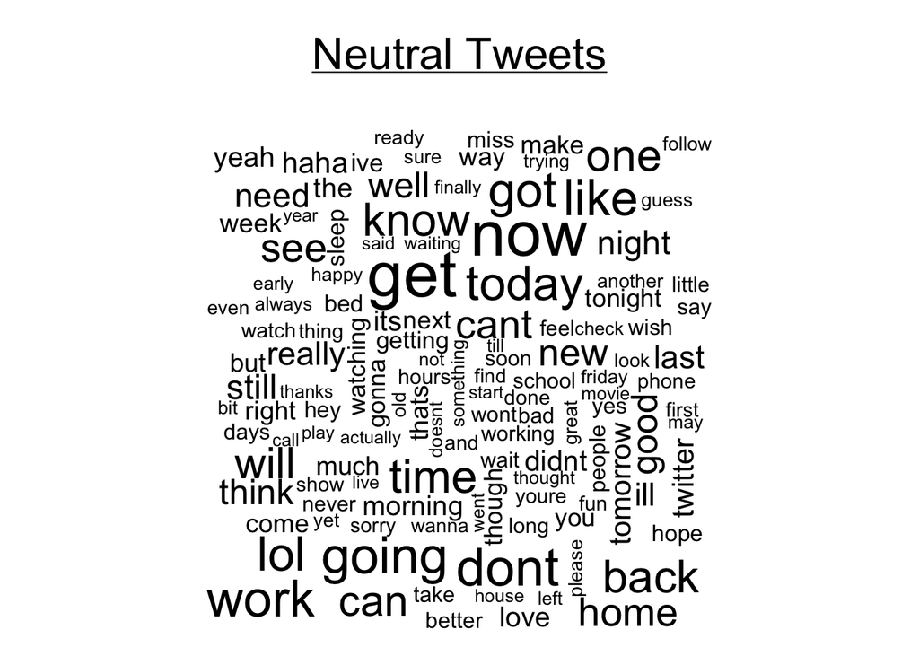

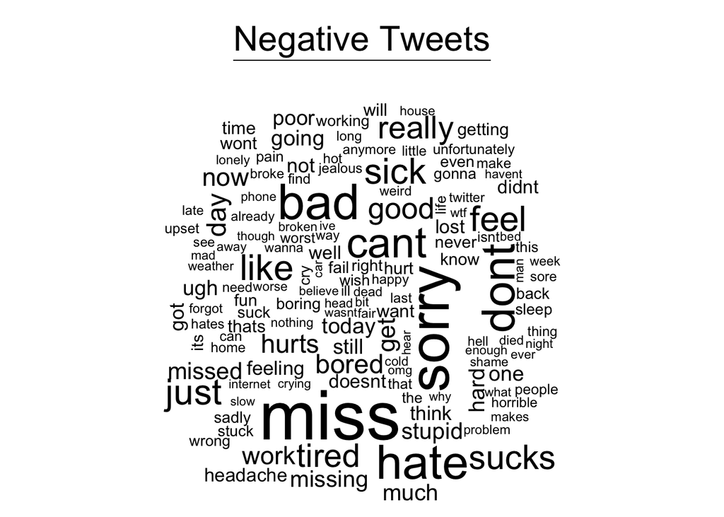

### Baseline submission

We’ll use a baseline submission that simply selects the entire text of the tweet as representative of the tweet’s sentiment. This results in a score of .594 on the test dataset.

```r
submission <- tibble(textID = test$textID,
                     selected_text = test$text_clean)
write.csv(submission, "submission-baseline.csv", row.names = FALSE, quote = 2)
```

## Modeling with XGBoost

While researching natural language processing and sentiment analysis, I’ve discovered that the best NLP tools are written in Python (which I’ll attempt to use in the next section). However, for the sake of practicing manipulating data in R and implementing an xgboost model, I will first try the following method ([inspired by this submission](https://www.kaggle.com/gomes555/ngram-predict-with-xgboost-h2o-in-r)):

1. For each tweet, calculate all possible combinations (ngrams) of “selected_text” for each textID, and create a new data frame where each combination of “selected_text” represents one row.
2. Add metadata columns to each row to represent features of each ngram, the original text, and the difference between the ngram and original. Will will use these features to **predict the Jaccard score of the ngram compared to the actual selected text.**
3. Use xgboost to model the Jaccard score of each ngram using all of the generated features from the original and selected ngram text.
4. With the model, predict the Jaccard score of the each test dataset ngram with the actual selected text, and **choose the ngram for each textID that has the highest predicted Jaccard score.**

### 1. Find all possible ngrams

After expanding the dataset to include all possible phrases (ngrams) that can be selected as capturing tweet sentiment, we have a table with 3,046,029 rows.

```r
### Expand Data Frames

# creates all ngram combinations from a phrase
create_ngrams <- function(text, nwords) {
  map(1:nwords,
      ~ get.ngrams(ngram(text, n = .x, sep = " "))) %>%
    unlist()
}
# converts strings into regex form
to_search <- function(x){
  str_replace_all(x, "([[:punct:]]|\\*|\\+|\\.{1,}|\\:|\\$|\\:|\\^|\\?|\\|)", "\\\\\\1")
}

expand_with_ngrams <- function(x) {
  # create data frame with all ngrams
  x_ngrams <- x %>%
    select(textID, text = text_clean, sentiment) %>%
    mutate(nwords = map_dbl(text, wordcount),
           ngram = map2(text, nwords, ~ create_ngrams(.x, .y))) %>%
    select(-nwords) %>%
    unnest(cols = c(ngram))
  # create columns for difference between selected and original
  x_ngrams <- x_ngrams %>%
  mutate(ngram_diff = str_remove(text, to_search(ngram)))
}

# add jaccard column
add_jaccard <- function(x, isTrain = TRUE) {
  if(isTrain == TRUE) x$jaccard <- map2_dbl(x$ngram, x$selected_text, ~ jaccard(.x, .y))
  else x$jaccard <- 0
  return(x)
}


# expand train and test data
train_ngrams <- expand_with_ngrams(train)
train_ngrams <- add_jaccard(train_ngrams)

test_ngrams <- expand_with_ngrams(test)
test_ngrams <- add_jaccard(test_ngrams, isTrain = FALSE)
```

#### Split Data by Sentiment

We will add a column to the training data to represent the difference between the ngram and the original text, and split the neutral sentiment from the positive and negative sentiment text.

I will leave the neutral data as is and only use xgboost to create predictions the positive and negative data for a couple of reasons:

1. Selecting the entire neutral text as the portion that captures its sentiment already achieves a (very good) Jaccard score of around 90%.
2. It is much more computationally reasonable to train a model on only the positive and negative tweets.
3. There are better methods for prediction that I will be attempting later, so a marginal increase in score doesn’t matter that much to me.

```r
# splits by sentiment
split_sentiment <- function (x, sent) {
  if (!(sent %in% c("positive", "negative", "neutral"))) return(print("Input a valid sentiment"))
  y  <- x %>%
    filter(sentiment == sent) %>%
    select(textID, text, sel = ngram, diff = ngram_diff, jaccard)
  return(y)
}

# split train and test data
pos_ngrams <- split_sentiment(train_ngrams, "positive")
neg_ngrams <- split_sentiment(train_ngrams, "negative")
neu_ngrams <- split_sentiment(train_ngrams, "neutral")

pos_ngrams_test <- split_sentiment(test_ngrams, "positive")
neg_ngrams_test <- split_sentiment(test_ngrams, "negative")
neu_ngrams_test <- split_sentiment(test_ngrams, "neutral")
```

### 2. Create Text Features

Let’s create some features to represent key aspects of the tweet text for our model.

For the original text, the selected ngram, and the remaining text, we will measure many text features, including the number of characters, words, lowercase/uppercase letters, types of punctuation, text sentiment, and more.

We will create our final predictors from this metadata by relating the selected/remaining text to the original text (i.e. proportion of characters, difference in sentiment etc.).

```r
# get metadata of character vector
get_metadata <- function (x) {
  print(Sys.time())
  metadata <- textfeatures(x, normalize = FALSE, word_dims = 0) %>%
    mutate(n_first_person = n_first_person + n_first_personp,         # combine 1st/2nd person cols
           n_second_person = n_second_person + n_second_personp) %>%
    select(-n_first_personp, -n_second_personp) %>%
    select(-n_uq_urls, -n_uq_hashtags, -n_uq_mentions,  # remove rows with near zero variance
           -n_nonasciis, -n_urls, -n_mentions)

    print(Sys.time())
  return(metadata)
}

# take raw metadata and create final predictors
parse_metadata <- function (x) {
  x <- x %>%
    mutate(selprop_n_hashtags = ifelse(orig_n_hashtags == 0, 0, sel_n_hashtags/orig_n_hashtags),
          selprop_n_chars = ifelse(orig_n_chars == 0, 0, sel_n_chars/orig_n_chars),
          selprop_n_uq_chars = ifelse(orig_n_uq_chars == 0, 0, sel_n_uq_chars/orig_n_uq_chars),
          selprop_n_commas = ifelse(orig_n_commas == 0, 0, sel_n_commas/orig_n_commas),
          selprop_n_digits = ifelse(orig_n_digits == 0, 0, sel_n_digits/orig_n_digits),
          selprop_n_exclaims = ifelse(orig_n_exclaims == 0, 0, sel_n_exclaims/orig_n_exclaims),
          selprop_n_extraspaces = ifelse(orig_n_extraspaces == 0, 0, sel_n_extraspaces/orig_n_extraspaces),
          selprop_n_lowers = ifelse(orig_n_lowers == 0, 0, sel_n_lowers/orig_n_lowers),
          selprop_n_lowersp = ifelse(orig_n_lowersp == 0, 0, sel_n_lowersp/orig_n_lowersp),
          selprop_n_periods = ifelse(orig_n_periods == 0, 0, sel_n_periods/orig_n_periods),
          selprop_n_words = ifelse(orig_n_words == 0, 0, sel_n_words/orig_n_words),
          selprop_n_uq_words = ifelse(orig_n_uq_words == 0, 0, sel_n_uq_words/orig_n_uq_words),
          selprop_n_caps = ifelse(orig_n_hashtags == 0, 0, sel_n_caps/orig_n_hashtags),
          selprop_n_puncts = ifelse(orig_n_caps == 0, 0, sel_n_puncts/orig_n_caps),
          selprop_n_capsp = ifelse(orig_n_capsp == 0, 0, sel_n_capsp/orig_n_capsp),
          selprop_n_charsperword = ifelse(orig_n_charsperword == 0, 0, sel_n_charsperword/orig_n_charsperword),
          selprop_sent_afinn = ifelse(orig_sent_afinn == 0, 0, sel_sent_afinn/orig_sent_afinn),
          selprop_sent_bing = ifelse(orig_sent_bing == 0, 0, sel_sent_bing/orig_sent_bing),
          selprop_sent_syuzhet = ifelse(orig_sent_syuzhet == 0, 0, sel_sent_syuzhet/orig_sent_syuzhet),
          selprop_sent_vader = ifelse(orig_sent_vader == 0, 0, sel_sent_vader/orig_sent_vader),
          selint_sent_afinn = orig_sent_afinn - sel_sent_afinn,
          selint_sent_bing = orig_sent_bing - sel_sent_bing,
          selint_sent_syuzhet = orig_sent_syuzhet - sel_sent_syuzhet,
          selint_sent_vader = orig_sent_vader - sel_sent_vader,
          selint_n_polite = orig_n_polite - sel_n_polite,
          selprop_n_first_person = ifelse(orig_n_first_person == 0, 0, sel_n_first_person/orig_n_first_person),
          selprop_n_second_person = ifelse(orig_n_second_person == 0, 0, sel_n_second_person/orig_n_second_person),
          selprop_n_third_person = ifelse(orig_n_third_person == 0, 0, sel_n_third_person/orig_n_third_person),
          selprop_n_tobe = ifelse(orig_n_tobe == 0, 0, sel_n_tobe/orig_n_tobe),
          selprop_n_prepositions = ifelse(orig_n_prepositions == 0, 0, sel_n_prepositions/orig_n_prepositions),
          diffprop_n_hashtags = ifelse(orig_n_hashtags == 0, 0, diff_n_hashtags/orig_n_hashtags),
          diffprop_n_chars = ifelse(orig_n_chars == 0, 0, diff_n_chars/orig_n_chars),
          diffprop_n_uq_chars = ifelse(orig_n_uq_chars == 0, 0, diff_n_uq_chars/orig_n_uq_chars),
          diffprop_n_commas = ifelse(orig_n_commas == 0, 0, diff_n_commas/orig_n_commas),
          diffprop_n_digits = ifelse(orig_n_digits == 0, 0, diff_n_digits/orig_n_digits),
          diffprop_n_exclaims = ifelse(orig_n_exclaims == 0, 0, diff_n_exclaims/orig_n_exclaims),
          diffprop_n_extraspaces = ifelse(orig_n_extraspaces == 0, 0, diff_n_extraspaces/orig_n_extraspaces),
          diffprop_n_lowers = ifelse(orig_n_lowers == 0, 0, diff_n_lowers/orig_n_lowers),
          diffprop_n_lowersp = ifelse(orig_n_lowersp == 0, 0, diff_n_lowersp/orig_n_lowersp),
          diffprop_n_periods = ifelse(orig_n_periods == 0, 0, diff_n_periods/orig_n_periods),
          diffprop_n_words = ifelse(orig_n_words == 0, 0, diff_n_words/orig_n_words),
          diffprop_n_uq_words = ifelse(orig_n_uq_words == 0, 0, diff_n_uq_words/orig_n_uq_words),
          diffprop_n_caps = ifelse(orig_n_hashtags == 0, 0, diff_n_caps/orig_n_hashtags),
          diffprop_n_puncts = ifelse(orig_n_caps == 0, 0, diff_n_puncts/orig_n_caps),
          diffprop_n_capsp = ifelse(orig_n_capsp == 0, 0, diff_n_capsp/orig_n_capsp),
          diffprop_n_charsperword = ifelse(orig_n_charsperword == 0, 0, diff_n_charsperword/orig_n_charsperword),
          diffprop_sent_afinn = ifelse(orig_sent_afinn == 0, 0, diff_sent_afinn/orig_sent_afinn),
          diffprop_sent_bing = ifelse(orig_sent_bing == 0, 0, diff_sent_bing/orig_sent_bing),
          diffprop_sent_syuzhet = ifelse(orig_sent_syuzhet == 0, 0, diff_sent_syuzhet/orig_sent_syuzhet),
          diffprop_sent_vader = ifelse(orig_sent_vader == 0, 0, diff_sent_vader/orig_sent_vader),
          diffint_sent_afinn = orig_sent_afinn - diff_sent_afinn,
          diffint_sent_bing = orig_sent_bing - diff_sent_bing,
          diffint_sent_syuzhet = orig_sent_syuzhet - diff_sent_syuzhet,
          diffint_sent_vader = orig_sent_vader - diff_sent_vader,
          diffint_n_polite = orig_n_polite - diff_n_polite,
          diffprop_n_first_person = ifelse(orig_n_first_person == 0, 0, diff_n_first_person/orig_n_first_person),
          diffprop_n_second_person = ifelse(orig_n_second_person == 0, 0, diff_n_second_person/orig_n_second_person),
          diffprop_n_third_person = ifelse(orig_n_third_person == 0, 0, diff_n_third_person/orig_n_third_person),
          diffprop_n_tobe = ifelse(orig_n_tobe == 0, 0, diff_n_tobe/orig_n_tobe),
          diffprop_n_prepositions = ifelse(orig_n_prepositions == 0, 0, diff_n_prepositions/orig_n_prepositions)
    )
}

# gets metadata of selected/diff text and combines them
# input: x = [pos|neg|neu]_ngrams, orig = original_metadata
get_all_metadata <- function(x, orig) {
  # get raw metadata
  sel_metadata <- bind_cols(textID = x$textID, get_metadata(x$sel)) %>%   # selected text, up to 30 min
    `colnames<-`(paste0("sel_", colnames(.)))
  diff_metadata <- bind_cols(textID = x$textID, get_metadata(x$diff)) %>%   # diff text, up to 30 min
    `colnames<-`(paste0("diff_", colnames(.)))
  all_metadata <- left_join(bind_cols(sel_metadata, select(diff_metadata, -diff_textID)),   # combine
                            orig,
                            by = c("sel_textID" = "orig_textID")) %>%
    rename(textID = sel_textID)
  # parse raw metadata into final predictors
  parsed_metadata <-  parse_metadata(all_metadata) %>%
    mutate(jaccard = x$jaccard) %>%
    select(textID, sel_n_words, sel_n_chars, orig_n_words, orig_n_chars,
           sel_sent_afinn, sel_sent_bing, sel_sent_syuzhet, sel_sent_vader,
           selprop_n_hashtags:jaccard)
  return(parsed_metadata)
}

### get final metadata for train and test data
orig_metadata <- bind_cols(textID = train$textID, get_metadata(train$text_clean)) %>%
  `colnames<-`(paste0("orig_", colnames(.)))
pos_metadata <- get_all_metadata(pos_ngrams, orig_metadata)
neg_metadata <- get_all_metadata(neg_ngrams, orig_metadata)

orig_metadata_test <- bind_cols(textID = test$textID, get_metadata(test$text_clean)) %>%
  `colnames<-`(paste0("orig_", colnames(.)))
pos_metadata_test <- get_all_metadata(pos_ngrams_test, orig_metadata_test)
neg_metadata_test <- get_all_metadata(neg_ngrams_test, orig_metadata_test)
```

### 3. Model Training

I used a basic xgboost model with no tuning to model the Jaccard score of each ngram using the newly created text features. The model was created with reasonable starting parameters (learning rate = .1, sample rate = .8, max depth = 5), and took about 25 minutes to run on Kaggle’s GPUs.

```r
h2o.init()

### prepare data
# train
all_metadata <- bind_rows(pos_metadata %>% mutate(sentiment = 1),
                          neg_metadata %>% mutate(sentiment = -1))
# remove the 6 least contributing predictors
worst_predictors <- c("selprop_n_lowers", "selprop_n_hashtags", "diffprop_n_chars", "diffprop_n_caps",
                      "diffprop_n_hashtags", "selprop_n_chars")
all_metadata <- all_metadata[, !(names(all_metadata) %in% worst_predictors)]
train_h2o <- all_metadata %>%
  select(-textID) %>%
  as.h2o()
x <- setdiff(colnames(train_h2o), c("jaccard"))
y <- "jaccard"

# test
all_metadata_test <- bind_rows(pos_metadata_test %>% mutate(sentiment = 1),
                               neg_metadata_test %>% mutate(sentiment = -1))
all_metadata_test <- all_metadata_test[, !(names(all_metadata) %in% worst_predictors)]
test_h2o <- all_metadata_test %>%
  select(-textID, -jaccard) %>%
  as.h2o

all_ngrams_test <- bind_rows(pos_ngrams_test, neg_ngrams_test)

# baseline xgboost model
 xgb1 <- h2o.xgboost(x, y, training_frame = train_h2o,
                     nfolds = 5,
                     seed = 2020,
                     ntrees = 1000, #
                     max_depth = 5, # default
                     learn_rate = .1,
                     sample_rate = .8,
                     colsample_bytree = 1, #default
                     gamma = 0, # default
                     # score_each_iteration = TRUE,
                     # score_tree_interval = 25,
                     stopping_rounds = 50,
                     stopping_metric = "MAE",
                     stopping_tolerance = .01)
```

#### Summary

A summary of the model is shown below. The model has a training set MAE (mean average error) of .1156, which is alright (but not great), given the Jaccard score ranges from 0 to 1.

I was expecting the model to stop early (before fitting all 1000 trees), but it turns out the MAE just kept decreasing. If I were to re-run this model, I would collect scoring information every 25 trees to determine a reasonable number of trees to stop at for further tuning.

```r
h2o.performance(xgb1)
```

```
## H2ORegressionMetrics: xgboost
## ** Reported on training data. **
##
## MSE:  0.02718712
## RMSE:  0.1648852
## MAE:  0.1156014
## RMSLE:  0.1256639
## Mean Residual Deviance :  0.02718712
```

#### Variable Importance

Taking a look at variable importance, we see that the top 5 variables that contribute to a higher Jaccard score for the selected text of positive and negative tweets are:

1. Sentiment of remaining text (VADER) / Sentiment of original text (VADER)
2. The number of characters in the original text
3. Sentiment of selected text (AFINN) / Sentiment of original text (AFINN)
4. The number of words in the original text
5. The proportion of unique words of selected text to original text

```r
h2o.varimp(xgb1)
```

```
## Variable Importances:
##              variable relative_importance scaled_importance percentage
## 1 diffprop_sent_vader        21784.373047          1.000000   0.139957
## 2        orig_n_chars        18281.714844          0.839212   0.117453
## 3  selprop_sent_afinn        11448.456055          0.525535   0.073552
## 4        orig_n_words         8234.158203          0.377985   0.052901
## 5  selprop_n_uq_words         6921.247070          0.317716   0.044466
##
## ---
##               variable relative_importance scaled_importance percentage
## 64    selprop_n_lowers          178.854584          0.008210   0.001149
## 65  selprop_n_hashtags          176.853897          0.008118   0.001136
## 66    diffprop_n_chars          168.695938          0.007744   0.001084
## 67     diffprop_n_caps          139.706314          0.006413   0.000898
## 68 diffprop_n_hashtags          113.071793          0.005191   0.000726
## 69     selprop_n_chars           78.632263          0.003610   0.000505
```

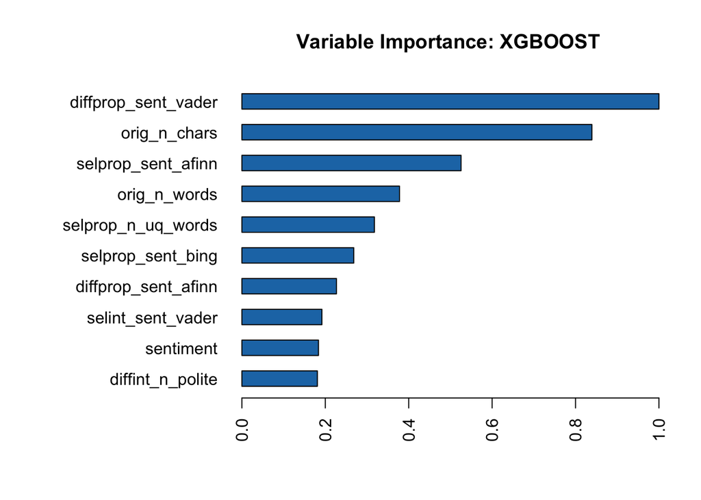

```r
h2o.varimp_plot(xgb1)
```

### 4. Prediction

```r
##### PREDICTION!
pred <- as_tibble(predict(xgb1, test_h2o))

### RESULTS
raw_results <- all_metadata_test %>%
  bind_cols(all_ngrams_test, pred) %>%
  select(textID, text, sel, predict) %>%
  group_by(textID) %>%
  top_n(1, predict)
```

There were two tweets where the predicted Jaccard score for two difference ngrams were the exact same. In this case, we select the ngram with fewer words.

Let’s take a look at the duplicates and the final results, and then write the submission file!

```r
# get duplicates
dup_results <- raw_results %>%
  filter(n() > 1) %>%
  ungroup()
head(dup_results) %>%
  kable() %>%
  kable_styling(bootstrap_options = c("responsive", "striped", "hover"))
```

| textID | text | sel | predict |
| --- | --- | --- | --- |
| f820ad932c | & more #<3criminy cuteness! http://tinyurl.com/cd8yab #sinfest | cuteness! | 0.4980760 |
| f820ad932c | & more #<3criminy cuteness! http://tinyurl.com/cd8yab #sinfest | cuteness! http://tinyurl.com/cd8yab | 0.4980760 |
| 2c39030bc4 | oh happy day!!! nice weather, smiling, happy baby and icecream later | happy day!!! nice weather, smiling, | 0.3709564 |
| 2c39030bc4 | oh happy day!!! nice weather, smiling, happy baby and icecream later | day!!! nice weather, smiling, happy | 0.3709564 |

```r
# get full results without duplicates
full_results <- raw_results %>%
  distinct(textID, predict, .keep_all = T) %>%
  ungroup()
head(full_results, 10)[-c(4, 5),] %>%
  kable() %>%
  kable_styling(bootstrap_options = c("responsive", "striped", "hover"))
```

| textID | text | sel | predict |
| --- | --- | --- | --- |
| 96d74cb729 | Shanghai is also really exciting (precisely – skyscrapers galore). Good tweeps in China: (SH) (BJ). | exciting (precisely – skyscrapers galore). Good | 0.2684941 |
| 01082688c6 | happy bday! | happy bday! | 0.7851430 |
| 33987a8ee5 | http://twitpic.com/4w75p - I like it!! | http://twitpic.com/4w75p - I like it!! | 0.6418817 |
| c50bdd4567 | thats so cool | thats so cool | 0.7582241 |
| 1fa8e6ad66 | look who I found just for you —> http://twitter.com/DJT2009 | look who I found just for you —> http://twitter.com/DJT20 | 0.4656549 |
| cce5c4744a | Watching Body of Lies…good film | Lies…good | 0.4326695 |
| c7f9d559e2 | Happy mothers day mumm xoxo | Happy | 0.6479106 |
| d3d7b13278 | Hi there. I agree! Small children should be running about happy, not breaking down in tears | happy, | 0.2869382 |

```r
# get final results
final_results <- full_results %>%
  select(textID, sel)

### SUBMISSION
# get positives
sub_pn <- test %>%
  filter(sentiment != "neutral") %>%
  left_join(full_results, by = "textID") %>%
  select(textID, selected_text = sel)
# get negatives
sub_neutrals <- test %>%
  filter(sentiment == "neutral") %>%
  select(textID, selected_text = text_clean)
# combine into full submission
sub <- bind_rows(sub_pn, sub_neutrals)

submission <- sample_submission %>%
  select(-selected_text) %>%
  left_join(sub, by = "textID")

write.csv(submission, "submission-xgboost.csv", row.names = FALSE, quote = 2)
```

### 5. Results

The xgboost model predictions resulted in a mean Jaccard score of .658 (calculated with 30% of the test data), which is in the top 78% of scores on Kaggle at the time of submission. This is a good improvement of our baseline submission of .594.

I expect that I could raise the prediction score a fair amount if I spent time tuning the hyperparameters of xgboost, but I won’t do that for the sake of time. Overall, I feel pretty good about the amount I’ve learned about natural language processing and all of the practice I’ve gotten with writing code in R.

Next, I’ll attempt to use a more modern, state-of-the-art language model for prediction. Stay tuned!

## Modeling with RoBERTa

While attempting to find a solution to this problem in R, I noticed that all of the high-scoring public kernels were written in Python using a state-of-the-art bidirectional transformer model called RoBERTa, which is an updated version of a similar model called BERT. In particular, many people were iterating on the code of [this PyTorch implementation of BERT](https://www.kaggle.com/abhishek/bert-base-uncased-using-pytorch) and [this Tensorflow implementation of RoBERTa](https://www.kaggle.com/cdeotte/tensorflow-roberta-0-705/comments).

I decided to take some time and familiarize myself with NLP models, word tokenization, transformers, self-attention, and BERT/RoBERTa using those two resources as a starting point.

### 1. Motivation and Overview

BERT and RoBERTa have a couple of advantages in comparison with my previous method:

- Directly chooses a portion of the tweet as the answer. This allows for the direct calculation of a cross-validation error rate that can approximate the actual submission error.
- Is able to select phrases based on character, effectively dealing with the weird cases we saw where the work splitting is not exactly on the space.
- Handles text comprehension and word context in a much more sophisticated way, since word associations have been trained on a very large English corpus (Wikipedia and BookCorpus for BERT, + additional sources for RoBERTa). Previously, we were only comparing the difference in positive/negative sentiment between the tweets and selected texts.

A simplified overview of the RoBERTa implementation with 5 folds that I used:

1. Tokenize the training and testing data in a format that can be recognized by RoBERTa.
2. Create a loss function to minimize the combined cross-entropy loss of the position of the selected text start index and the selected text end index.
3. Load a pre-trained RoBERTa model, and use tensorflow to add neural network layers to estimate the probability of start/end index, using the AdamW optimizer.
4. Split the data into 5 folds, shuffle the data, and train the model for 3 epochs. For each fold, select the best start and end indexes for the selected tweet text for the out-of-fold training data.
5. From all 5 model predictions for the test data, average the probabilities of each word in the each tweet being the start and end of the selected tweet text. Finally, choose the start and end index for each tweet with the highest probability.
6. Perform minimal preprocessing on the final output to account for noise in the data.

### 2. Failed Attempts

I tried many things that didn’t increase my score, including:

- Using pseudolabels with the full dataset of tweets
- Adding additional sentiment for each tweet from the full dataset that the tweets were taken from
- Different encoding methods/formats when passing data into RoBERTa
- Passing additional information about the tweet (word length, number of characters) into RoBERTa

### 3. Final Model and Results

[Link to final model on Kaggle!](https://www.kaggle.com/panthonies/roberta-ensemble-top-6)

For my final submission, I used an ensemble of two RoBERTa models that scored fairly well individually (.715 and .714 on the public leaderboard). In the end, I found it difficult to improve much on the solid baseline models that were publicly available.

Very big thanks to [Chris Deotte](https://www.kaggle.com/cdeotte/tensorflow-roberta-0-705/comments) and [Sazuma](https://www.kaggle.com/shoheiazuma/tweet-sentiment-roberta-pytorch) for their great public kernels that I used as a starting point.

The model scored .71735 on the final leaderboad, which was in the top 6% of solutions.